# Praktikum 4 - Proses MA(2), AR(2), dan ARMA(2,2)

Daffa Faaiz Al-Zakkii | M0401241027

2026-09-15

# 1 Library

```r
library(TSA)
library(forecast)
```

```r
library(ggplot2)
library(gridExtra)
library(knitr)
```

Fungsi bantu berikut dipakai berulang kali untuk membandingkan ACF/PACF teoritis vs empiris, supaya logikanya **persis sama** di ketiga bagian (MA, AR, ARMA).

```r
buat_tabel_acf <- function(data_ts, lag_maks, ar = numeric(0), ma = numeric(0), pacf = FALSE) {

  teori <- stats::ARMAacf(ar = ar, ma = ma, lag.max = lag_maks, pacf = pacf)
  if (!pacf) teori <- teori[-1]
  teori <- as.numeric(teori)

  if (pacf) {
    empiris <- as.numeric(drop(stats::pacf(data_ts, lag.max = lag_maks, plot = FALSE)$acf))
  } else {
    empiris <- as.numeric(drop(stats::acf(data_ts, lag.max = lag_maks, plot = FALSE)$acf))[-1]
  }

  data.frame(
    Lag      = 1:lag_maks,
    Teoritis = round(teori, 4),
    Empiris  = round(empiris, 4)
  )
}

lag_maks <- 5
```

# 2 Proses MA(2)

## 2.1 Membangkitkan Data

### 2.1.1 Cara Manual

Dibangkitkan dengan menuliskan sendiri rumus rekursif MA(2). Ditambahkan *burn-in* 50 data di awal supaya proses sudah “settle” sebelum data yang dipakai diambil (walaupun untuk MA ini efeknya kecil karena tidak ada ketergantungan ke masa lalu yang panjang, tetap dilakukan agar konsisten dengan proses AR dan ARMA nanti).

> Perlu digarisbawahi bahwa `set.seed(123)` dipanggil ulang persis sebelum `rnorm()` di bagian MA(2), AR(2), maupun ARMA(2,2) Karena panjang (`N`) dan parameter `rnorm()`-nya sama, ketiga vektor *white noise* tersebut sebenarnya **identik**, bukan tiga realisasi acak yang independen. Ini bukan kesalahan yang membatalkan hasil, tujuannya supaya perbandingan karakteristik antar-proses memakai basis error yang sama/adil, tetapi perlu disadari saat membaca hasil.

```r
set.seed(123)
n     <- 300
burn  <- 50
N     <- n + burn

theta1 <- 0.4
theta2 <- 0.6

e <- rnorm(N, mean = 0, sd = 1)
y_ma2 <- numeric(N)

for (t in 3:N) {
  y_ma2[t] <- e[t] + theta1 * e[t - 1] + theta2 * e[t - 2]
}

y_ma2_manual <- ts(y_ma2[(burn + 1):N])
head(y_ma2_manual, 10)
```

```
## Time Series:
## Start = 1
## End = 10
## Frequency = 1
##  [1]  0.68794996  0.02275921  0.09770195  1.33432605  0.29594765  2.24732358
##  [7] -1.07762715  0.87499499 -0.57155194  0.61625152
```

### 2.1.2 Menggunakan `arima.sim()`

```r
set.seed(123)
y_ma2_sim <- stats::arima.sim(model = list(ma = c(theta1, theta2)), n = n)
head(y_ma2_sim, 10)
```

```
## Time Series:
## Start = 1
## End = 10
## Frequency = 1
##  [1]  1.13035193  0.55588522  1.09271608  1.80908512  1.22451484 -0.05165576
##  [7] -0.91632762 -1.47943985  0.63370530  0.58204936
```

Nilai-nilai di atas jelas beda dengan hasil manual, karena random number generator dipanggil dengan urutan yang berbeda di dalam `arima.sim()`. Yang penting bukan nilainya sama persis, tapi **karakteristik statistiknya** (rata-rata sekitar 0, ACF cut-off di lag 2) harus konsisten. Itu yang akan dicek di bagian berikutnya.

## 2.2 Plot Time Series

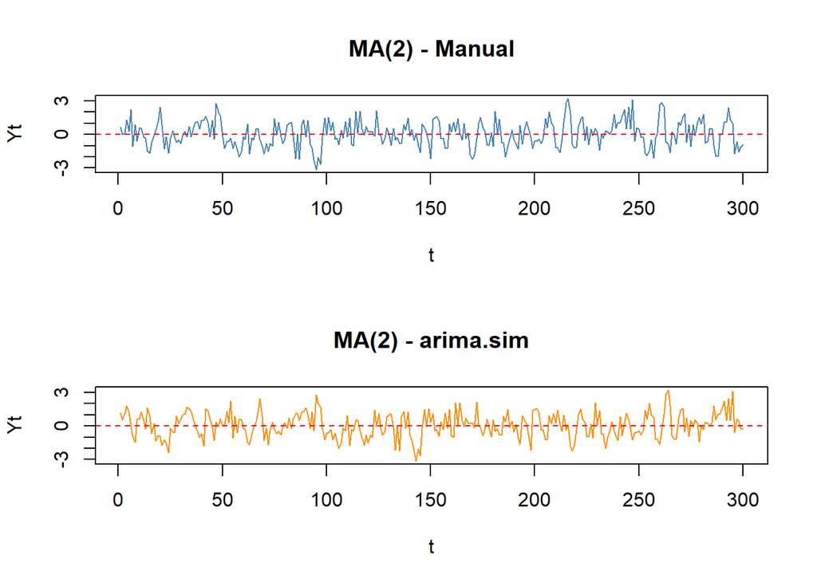

```r
par(mfrow = c(2, 1))
plot(y_ma2_manual, main = "MA(2) - Manual", ylab = "Yt", xlab = "t", col = "steelblue")
abline(h = 0, lty = 2, col = "red")
plot(y_ma2_sim, main = "MA(2) - arima.sim", ylab = "Yt", xlab = "t", col = "darkorange")
abline(h = 0, lty = 2, col = "red")
```

```r
par(mfrow = c(1, 1))
```

**Interpretasi:** kedua plot berfluktuasi di sekitar angka 0 dengan lebar sebaran (varians) yang relatif konstan sepanjang waktu, tidak ada tren naik/turun maupun perubahan pola musiman. Ini ciri khas data yang **stasioner dalam rata-rata dan varians**. Sesuai teori, memang MA(2) pasti stasioner berapa pun nilai $\theta_1$ dan $\theta_2$-nya.

> **Cek invertibilitas:** stasioner otomatis untuk MA berorde berapa pun, tapi *invertibilitas* (agar MA(2) bisa dituliskan ulang sebagai AR(∞) dan diidentifikasi PACF-nya) tidak otomatis dan tetap perlu dicek dari akar polinomial MA-nya. Cara paling aman dan tidak tergantung konvensi tanda adalah lewat akar polinomial:

```r
roots_ma <- polyroot(c(1, theta1, theta2))
Mod(roots_ma)
```

```
## [1] 1.290994 1.290994
```

Karena modulus kedua akar > 1, MA(2) dengan $\theta_1=0.4$ dan $\theta_2=0.6$ ini **invertible**.

## 2.3 ACF, PACF, dan EACF

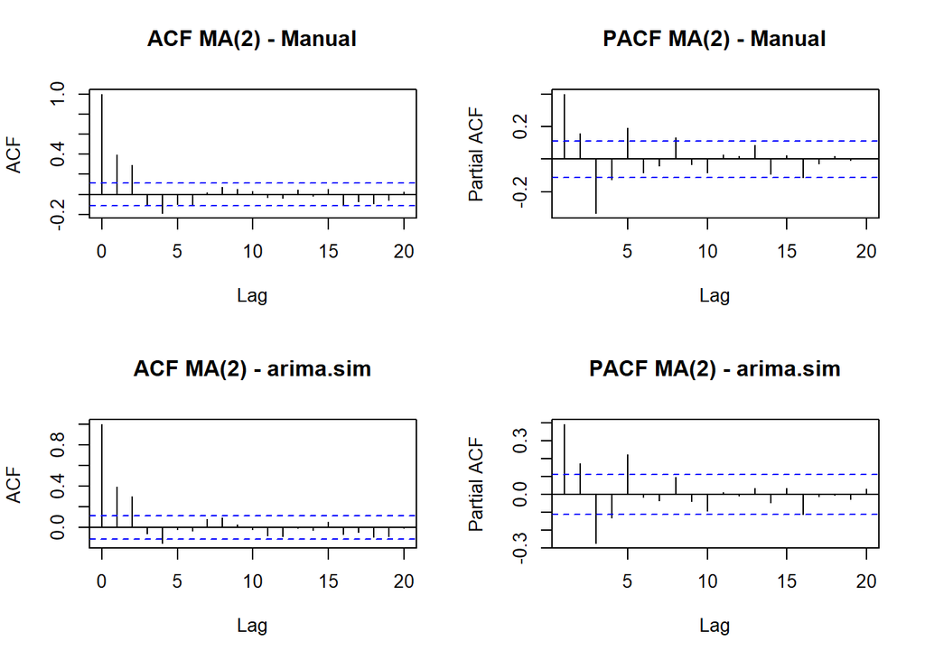

```r
par(mfrow = c(2, 2))
stats::acf(y_ma2_manual, lag.max = 20, main = "ACF MA(2) - Manual")
stats::pacf(y_ma2_manual, lag.max = 20, main = "PACF MA(2) - Manual")
stats::acf(y_ma2_sim, lag.max = 20, main = "ACF MA(2) - arima.sim")
stats::pacf(y_ma2_sim, lag.max = 20, main = "PACF MA(2) - arima.sim")
```

```r
par(mfrow = c(1, 1))
```

```r
cat("EACF untuk MA(2): data manual\n")
```

```
## EACF untuk MA(2): data manual
```

```r
eacf(y_ma2_manual)
```

```
## AR/MA
##   0 1 2 3 4 5 6 7 8 9 10 11 12 13
## 0 x x o x o o o o o o o  o  o  o
## 1 x x x x o o o o o o o  o  o  o
## 2 x x x x o x o o o o o  o  o  o
## 3 x x x x x x o o o o o  o  o  o
## 4 x x o x o o o o o o o  o  o  o
## 5 x x o x x o o o o o o  o  o  o
## 6 x x x x o o o o o o o  o  o  o
## 7 x x x x x o o o o o o  o  o  o
```

## 2.4 Scatterplot $Y_t$ vs Lag

```r
y_ma2_num <- as.numeric(y_ma2_manual)
n_ma2 <- length(y_ma2_num)

df_ma2 <- data.frame(
  Yt   = y_ma2_num,
  Yt1  = c(NA, y_ma2_num[-n_ma2]),
  Yt2  = c(NA, NA, y_ma2_num[1:(n_ma2 - 2)]),
  Yt3  = c(NA, NA, NA, y_ma2_num[1:(n_ma2 - 3)])
)
```

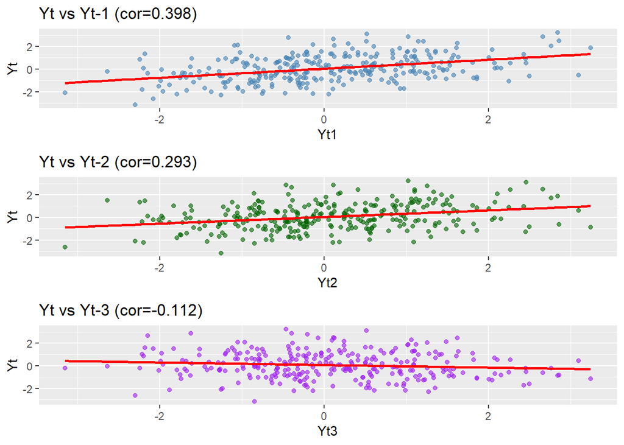

```r
p1 <- ggplot(df_ma2, aes(Yt1, Yt)) + geom_point(alpha = 0.6, color = "steelblue") +
  geom_smooth(method = "lm", se = FALSE, color = "red") +
  labs(title = paste0("Yt vs Yt-1 (cor=", round(cor(df_ma2$Yt, df_ma2$Yt1, use="complete.obs"),3),")"))

p2 <- ggplot(df_ma2, aes(Yt2, Yt)) + geom_point(alpha = 0.6, color = "darkgreen") +
  geom_smooth(method = "lm", se = FALSE, color = "red") +
  labs(title = paste0("Yt vs Yt-2 (cor=", round(cor(df_ma2$Yt, df_ma2$Yt2, use="complete.obs"),3),")"))

p3 <- ggplot(df_ma2, aes(Yt3, Yt)) + geom_point(alpha = 0.6, color = "purple") +
  geom_smooth(method = "lm", se = FALSE, color = "red") +
  labs(title = paste0("Yt vs Yt-3 (cor=", round(cor(df_ma2$Yt, df_ma2$Yt3, use="complete.obs"),3),")"))

grid.arrange(p1, p2, p3, ncol = 1)
```

**Interpretasi:** titik-titik pada $Y_t$ vs $Y_{t-1}$ dan $Y_t$ vs $Y_{t-2}$ menunjukkan pola linear yang cukup terlihat (garis merah tidak datar), sedangkan pada $Y_t$ vs $Y_{t-3}$ titik-titiknya menyebar acak tanpa pola (garis merah nyaris datar). Ini sejalan dengan teori:  
korelasi antara $Y_t$ dan $Y_{t-k}$ untuk MA(2) hanya ada sampai $k=2$, sedangkan $k=3$ ke atas seharusnya sekitar nol.

## 2.5 Autokorelasi: Empiris vs Teoritis

```r
rho1_teori <- (theta1 + theta1*theta2) / (1 + theta1^2 + theta2^2)
rho2_teori <- theta2 / (1 + theta1^2 + theta2^2)

tabel_ma2 <- buat_tabel_acf(y_ma2_manual, lag_maks, ma = c(theta1, theta2))
kable(tabel_ma2, caption = "Perbandingan ACF Teoritis vs Empiris - MA(2)")
```

Perbandingan ACF Teoritis vs Empiris - MA(2)

| Lag | Teoritis | Empiris |
| --- | --- | --- |
| 1 | 0.4211 | 0.3978 |
| 2 | 0.3947 | 0.2923 |
| 3 | 0.0000 | -0.1115 |
| 4 | 0.0000 | -0.1891 |
| 5 | 0.0000 | -0.0966 |

Secara manual (rumus), $\rho_1 = 0.4211$ dan $\rho_2 = 0.3947$, sedangkan lag 3 dan seterusnya teoritis persis 0. Dari tabel di atas terlihat nilai empiris (dari 300 data bangkitan) mendekati nilai teoritisnya, meskipun tidak identik. Ini wajar karena ini hanya satu realisasi/sampel dari proses stokastiknya, bukan populasi. Semakin banyak data dibangkitkan, nilai empiris akan makin mendekati nilai teoritis (hukum bilangan besar).

# 3 Proses AR(2)

## 3.1 Membangkitkan Data

### 3.1.1 Cara Manual

```r
set.seed(123)
phi1 <- 0.5
phi2 <- 0.2

e2 <- rnorm(N, mean = 0, sd = 1)
y_ar2 <- numeric(N)

for (t in 3:N) {
  y_ar2[t] <- phi1 * y_ar2[t - 1] + phi2 * y_ar2[t - 2] + e2[t]
}

y_ar2_manual <- ts(y_ar2[(burn + 1):N])
head(y_ar2_manual, 10)
```

```
## Time Series:
## Start = 1
## End = 10
## Frequency = 1
##  [1]  0.3696158  0.1648268  0.1134661  1.4583007  0.5260726  2.0711670
##  [7] -0.4079548  0.7948698  0.4396982  0.5947646
```

### 3.1.2 Menggunakan `arima.sim()`

```r
set.seed(123)
y_ar2_sim <- stats::arima.sim(model = list(ar = c(phi1, phi2)), n = n)
head(y_ar2_sim, 10)
```

```
## Time Series:
## Start = 1
## End = 10
## Frequency = 1
##  [1] -2.9518714 -1.0047928 -0.9393975 -1.8087943  0.1615383  0.1454745
##  [7] -0.1900266  0.8292073  1.2547318  1.6147884
```

## 3.2 Plot Time Series

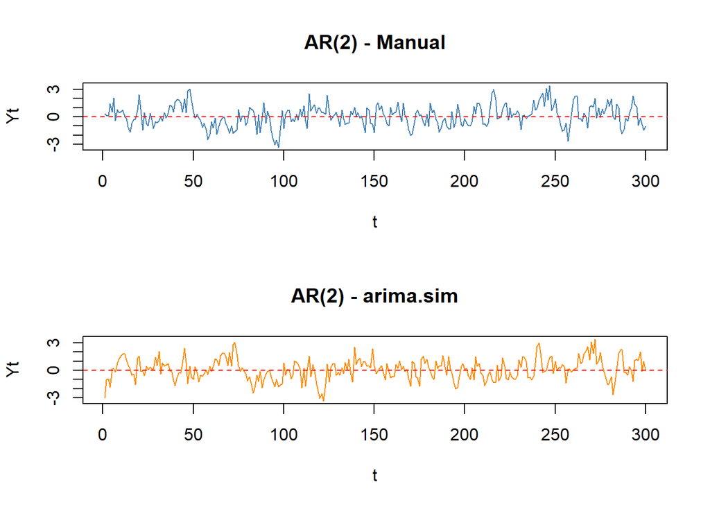

```r
par(mfrow = c(2, 1))
plot(y_ar2_manual, main = "AR(2) - Manual", ylab = "Yt", xlab = "t", col = "steelblue")
abline(h = 0, lty = 2, col = "red")
plot(y_ar2_sim, main = "AR(2) - arima.sim", ylab = "Yt", xlab = "t", col = "darkorange")
abline(h = 0, lty = 2, col = "red")
```

```r
par(mfrow = c(1, 1))
```

**Interpretasi:** sama seperti MA(2), plot berayun di sekitar nol dengan varians yang relatif stabil. Bedanya, pola pergerakan AR(2) terlihat sedikit lebih “halus”/smooth dibanding MA(2), karena nilai sekarang dipengaruhi nilai-nilai sebelumnya (ada ketergantungan/*persistence*), bukan cuma error acak.

## 3.3 ACF, PACF, dan EACF

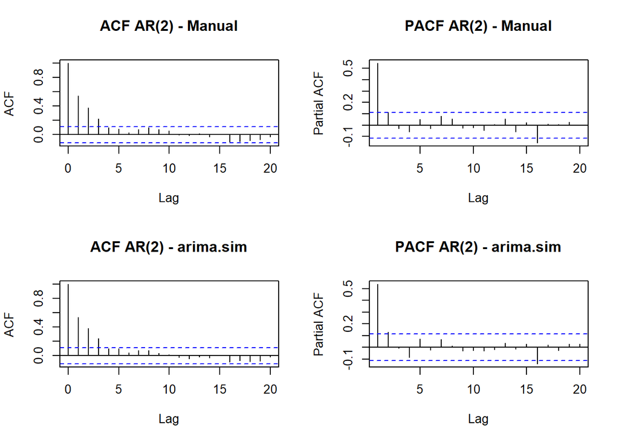

```r
par(mfrow = c(2, 2))
stats::acf(y_ar2_manual, lag.max = 20, main = "ACF AR(2) - Manual")
stats::pacf(y_ar2_manual, lag.max = 20, main = "PACF AR(2) - Manual")
stats::acf(y_ar2_sim, lag.max = 20, main = "ACF AR(2) - arima.sim")
stats::pacf(y_ar2_sim, lag.max = 20, main = "PACF AR(2) - arima.sim")
```

```r
par(mfrow = c(1, 1))
```

```r
cat("EACF untuk AR(2) - data manual\n")
```

```
## EACF untuk AR(2) - data manual
```

```r
eacf(y_ar2_manual)
```

```
## AR/MA
##   0 1 2 3 4 5 6 7 8 9 10 11 12 13
## 0 x x x o o o o o o o o  o  o  o
## 1 x o o o o o o o o o o  o  o  o
## 2 x x o o o o o o o o o  o  o  o
## 3 x x o o o x o o o o o  o  o  o
## 4 x o o o o x o o o o o  o  o  o
## 5 x x o x o o o o o o o  o  o  o
## 6 x x o x x o o o o o o  o  o  o
## 7 x x o x x o o o o o o  o  o  o
```

**Interpretasi ACF/PACF/EACF:**

- **ACF** meluruh perlahan (tails off), tidak langsung terpotong di lag tertentu, mengonfirmasi adanya proses AR.
- **PACF** signifikan jelas di lag 1. Di lag 2, nilai empirisnya (≈0.113, lihat tabel PACF di bagian Autokorelasi) berada nyaris tepat di garis signifikansi ±1.96/√300≈0.113, jadi secara visual agak samar. Ini bukan berarti orde AR = 2 salah, secara *teoritis* PACF lag 2 untuk proses ini memang $\phi_2=0.2$ (tidak nol), hanya saja pada satu realisasi sampel (n=300) nilainya kebetulan lemah karena variasi sampling, jadi “cut off lag 2” di sini lebih tepat disebut didukung teori, bukan terlihat setegas contoh buku teks.
- **EACF** perlu dicermati lebih teliti: pada tabel di atas, sel (AR = 2, MA = 0) itu sendiri masih bertanda “x”, bukan “o”. Pola segitiga nol yang benar-benar konsisten (semua “o” ke kanan dan ke bawah) baru mulai rapi sekitar kolom MA = 2, bukan MA = 0. Ini gejala umum EACF dari data simulasi ukuran terbatas (n=300) yang jarang membentuk segitiga sempurna seperti pada ilustrasi buku teks. Kesimpulan identifikasi tetap mengarah ke proses AR berorde rendah (konsisten dengan AR(2) yang sebenarnya), tapi klaim “vertex tepat di AR=2, MA=0” dari tabel ini saja kurang akurat dan sebaiknya dikombinasikan dengan hasil ACF/PACF di atas, bukan berdiri sendiri.

## 3.4 Scatterplot $Y_t$ vs Lag

```r
y_ar2_num <- as.numeric(y_ar2_manual)
n_ar2 <- length(y_ar2_num)

df_ar2 <- data.frame(
  Yt   = y_ar2_num,
  Yt1  = c(NA, y_ar2_num[-n_ar2]),
  Yt2  = c(NA, NA, y_ar2_num[1:(n_ar2 - 2)]),
  Yt3  = c(NA, NA, NA, y_ar2_num[1:(n_ar2 - 3)])
)
```

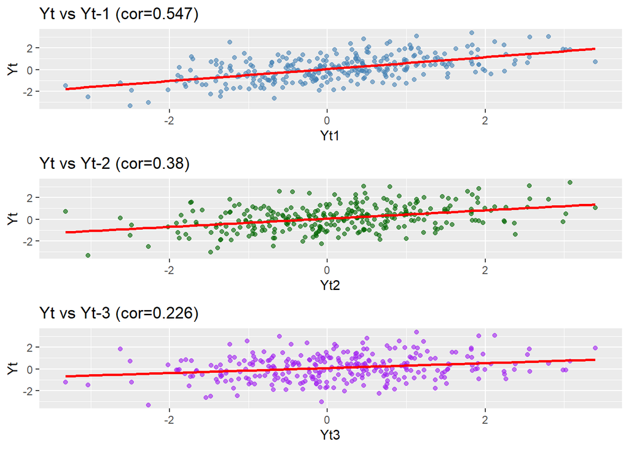

```r
p1 <- ggplot(df_ar2, aes(Yt1, Yt)) + geom_point(alpha = 0.6, color = "steelblue") +
  geom_smooth(method = "lm", se = FALSE, color = "red") +
  labs(title = paste0("Yt vs Yt-1 (cor=", round(cor(df_ar2$Yt, df_ar2$Yt1, use="complete.obs"),3),")"))

p2 <- ggplot(df_ar2, aes(Yt2, Yt)) + geom_point(alpha = 0.6, color = "darkgreen") +
  geom_smooth(method = "lm", se = FALSE, color = "red") +
  labs(title = paste0("Yt vs Yt-2 (cor=", round(cor(df_ar2$Yt, df_ar2$Yt2, use="complete.obs"),3),")"))

p3 <- ggplot(df_ar2, aes(Yt3, Yt)) + geom_point(alpha = 0.6, color = "purple") +
  geom_smooth(method = "lm", se = FALSE, color = "red") +
  labs(title = paste0("Yt vs Yt-3 (cor=", round(cor(df_ar2$Yt, df_ar2$Yt3, use="complete.obs"),3),")"))

grid.arrange(p1, p2, p3, ncol = 1)
```

**Interpretasi:** berbeda dengan MA(2), di sini pola linear masih cukup terlihat bahkan sampai $Y_t$ vs $Y_{t-3}$, walau kemiringannya makin landai (korelasi makin kecil seiring lag makin jauh). Ini karena pada AR, ketergantungan antar waktu bersifat “menular” terus ke lag-lag berikutnya (meluruh, tidak putus tiba-tiba), berbeda dengan MA yang ketergantungannya benar-benar berhenti setelah lag $q$.

**Verifikasi numerik syarat stasioner:**

```r
phi1 + phi2        # harus < 1
```

```
## [1] 0.7
```

```r
phi2 - phi1        # harus < 1
```

```
## [1] -0.3
```

```r
abs(phi2)          # harus < 1
```

```
## [1] 0.2
```

```r
roots_ar <- polyroot(c(1, -phi1, -phi2))
Mod(roots_ar)
```

```
## [1] 1.311738 3.811738
```

Ketiga syarat segitiga kestasioneran AR(2) terpenuhi, dan kedua akar polinomial karakteristiknya berada di luar lingkaran satuan. Jadi proses AR(2) ini terbukti **stasioner secara numerik**, bukan sekadar dugaan dari plot.

## 3.5 Autokorelasi: Empiris vs Teoritis

```r
rho1_ar_teori <- phi1 / (1 - phi2)
rho2_ar_teori <- phi1*rho1_ar_teori + phi2*1
rho3_ar_teori <- phi1*rho2_ar_teori + phi2*rho1_ar_teori

tabel_ar2 <- buat_tabel_acf(y_ar2_manual, lag_maks, ar = c(phi1, phi2))
kable(tabel_ar2, caption = "Perbandingan ACF Teoritis vs Empiris - AR(2)")
```

Perbandingan ACF Teoritis vs Empiris - AR(2)

| Lag | Teoritis | Empiris |
| --- | --- | --- |
| 1 | 0.6250 | 0.5461 |
| 2 | 0.5125 | 0.3777 |
| 3 | 0.3812 | 0.2248 |
| 4 | 0.2931 | 0.1007 |
| 5 | 0.2228 | 0.0833 |

Dari rumus Yule-Walker: $\rho_1=0.625$, $\rho_2=0.5125$, $\rho_3=0.3812$, dan seterusnya meluruh menuju 0 tapi tidak pernah benar-benar putus. Nilai empiris pada tabel di atas cukup dekat dengan nilai teoritisnya, meskipun selisihnya sedikit lebih besar dibanding kasus MA(2). Ini masuk akal karena pada AR, efek estimasi (dari data yang terbatas dan adanya feedback antar-lag) terakumulasi sepanjang waktu.

Selain ACF, bisa juga dicek PACF secara teoritis:

```r
tabel_pacf_ar2 <- buat_tabel_acf(y_ar2_manual, lag_maks, ar = c(phi1, phi2), pacf = TRUE)
kable(tabel_pacf_ar2, caption = "Perbandingan PACF Teoritis vs Empiris - AR(2)")
```

Perbandingan PACF Teoritis vs Empiris - AR(2)

| Lag | Teoritis | Empiris |
| --- | --- | --- |
| 1 | 0.625 | 0.5461 |
| 2 | 0.200 | 0.1132 |
| 3 | 0.000 | -0.0287 |
| 4 | 0.000 | -0.0596 |
| 5 | 0.000 | 0.0530 |

Terlihat PACF teoritis sudah 0 (mendekati 0) mulai lag 3, sesuai definisi bahwa AR(2) hanya punya 2 PACF signifikan.

# 4 Proses ARMA(2,2)

## 4.1 Membangkitkan Data

### 4.1.1 Cara Manual

```r
set.seed(123)
e3 <- rnorm(N, mean = 0, sd = 1)
y_arma22 <- numeric(N)

for (t in 3:N) {
  y_arma22[t] <- phi1 * y_arma22[t - 1] + phi2 * y_arma22[t - 2] +
                 e3[t] + theta1 * e3[t - 1] + theta2 * e3[t - 2]
}

y_arma22_manual <- ts(y_arma22[(burn + 1):N])
head(y_arma22_manual, 10)
```

```
## Time Series:
## Start = 1
## End = 10
## Frequency = 1
##  [1] 0.6713957 0.3383694 0.4011658 1.6025828 1.1774722 3.1565762 0.7361554
##  [8] 1.8743879 0.5128731 1.2475657
```

### 4.1.2 Menggunakan `arima.sim()`

```r
set.seed(123)
y_arma22_sim <- stats::arima.sim(model = list(ar = c(phi1, phi2), ma = c(theta1, theta2)), n = n)
head(y_arma22_sim, 10)
```

```
## Time Series:
## Start = 1
## End = 10
## Frequency = 1
##  [1] -3.11187150 -2.78699743 -1.12528900 -0.87493596 -0.03472262  0.84062710
##  [7]  1.47250989  2.61429024  3.14579988  3.41808039
```

## 4.2 Plot Time Series

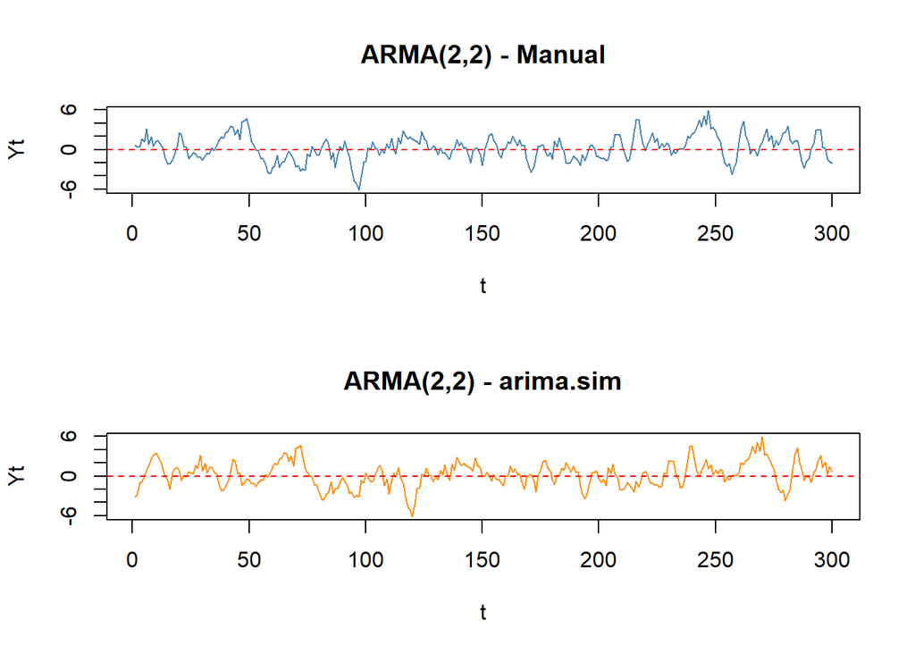

```r
par(mfrow = c(2, 1))
plot(y_arma22_manual, main = "ARMA(2,2) - Manual", ylab = "Yt", xlab = "t", col = "steelblue")
abline(h = 0, lty = 2, col = "red")
plot(y_arma22_sim, main = "ARMA(2,2) - arima.sim", ylab = "Yt", xlab = "t", col = "darkorange")
abline(h = 0, lty = 2, col = "red")
```

```r
par(mfrow = c(1, 1))
```

**Interpretasi:** seperti dua proses sebelumnya, data berfluktuasi stabil di sekitar 0 tanpa tren maupun perubahan varians yang mencolok sepanjang waktu observasi → **stasioner**, sesuai hasil pengecekan syarat kestasioneran bagian AR di atas.

> **Syarat ARMA(2,2):** untuk proses campuran, dua syarat harus dicek terpisah: kestasioneran ditentukan hanya oleh bagian AR-nya, dan invertibilitas ditentukan hanya oleh bagian MA-nya. Karena $\phi_1,\phi_2$ dan $\theta_1,\theta_2$ di sini persis sama dengan yang sudah diverifikasi sebelumnya, kedua syarat tersebut otomatis ikut terpenuhi:

```r
Mod(polyroot(c(1, -phi1, -phi2)))
```

```
## [1] 1.311738 3.811738
```

```r
Mod(polyroot(c(1, theta1, theta2)))
```

```
## [1] 1.290994 1.290994
```

Karena seluruh akar dari kedua polinomial berada di luar lingkaran satuan, ARMA(2,2) dengan parameter ini terbukti **stasioner sekaligus invertible**.

## 4.3 ACF, PACF, dan EACF

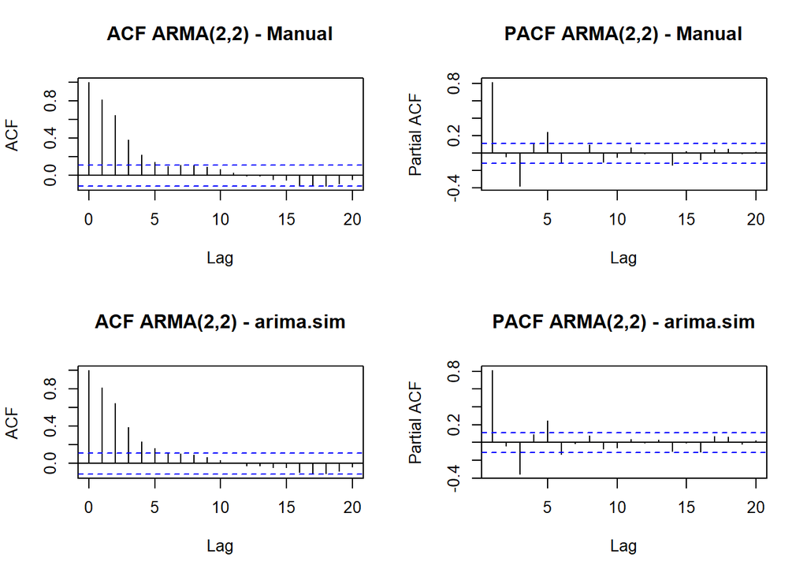

```r
par(mfrow = c(2, 2))
stats::acf(y_arma22_manual, lag.max = 20, main = "ACF ARMA(2,2) - Manual")
stats::pacf(y_arma22_manual, lag.max = 20, main = "PACF ARMA(2,2) - Manual")
stats::acf(y_arma22_sim, lag.max = 20, main = "ACF ARMA(2,2) - arima.sim")
stats::pacf(y_arma22_sim, lag.max = 20, main = "PACF ARMA(2,2) - arima.sim")
```

```r
par(mfrow = c(1, 1))
```

```r
cat("EACF untuk ARMA(2,2) - data manual\n")
```

```
## EACF untuk ARMA(2,2) - data manual
```

```r
eacf(y_arma22_manual)
```

```
## AR/MA
##   0 1 2 3 4 5 6 7 8 9 10 11 12 13
## 0 x x x x x o o o o o o  o  o  o
## 1 o x o o o x o o o o o  o  o  o
## 2 o x o o o x o o o o o  o  o  o
## 3 x x o x o x o o o o o  o  o  o
## 4 x x o x o x o o o o o  o  o  o
## 5 x x x x o o o o o o o  o  o  o
## 6 o x o x o o o o o o o  o  o  o
## 7 o x o x o o o o o o o  o  o  o
```

## 4.4 Scatterplot $Y_t$ vs Lag

```r
y_arma22_num <- as.numeric(y_arma22_manual)
n_arma22 <- length(y_arma22_num)

df_arma22 <- data.frame(
  Yt   = y_arma22_num,
  Yt1  = c(NA, y_arma22_num[-n_arma22]),
  Yt2  = c(NA, NA, y_arma22_num[1:(n_arma22 - 2)]),
  Yt3  = c(NA, NA, NA, y_arma22_num[1:(n_arma22 - 3)])
)
```

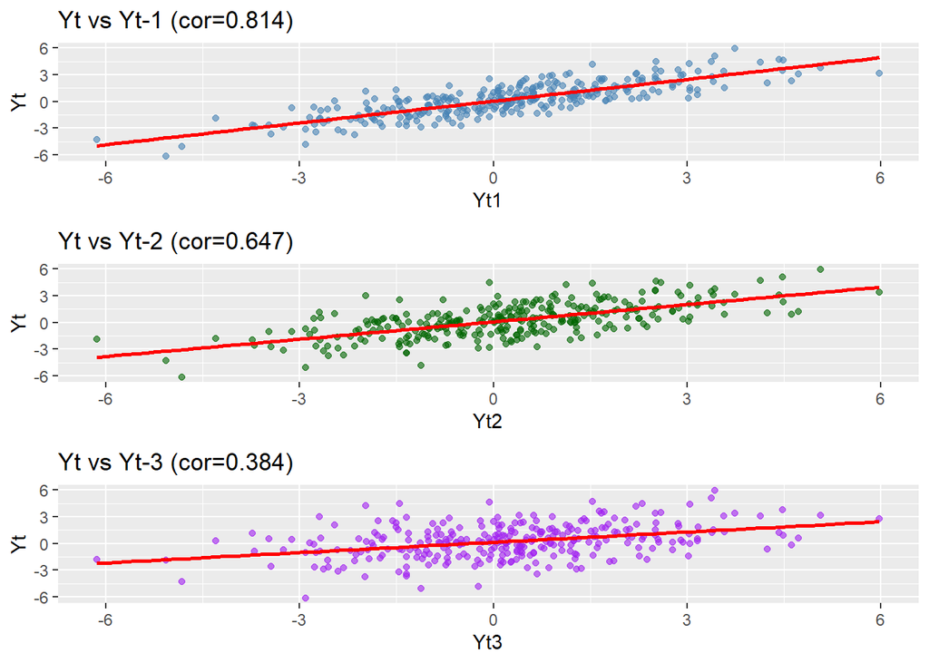

```r
p1 <- ggplot(df_arma22, aes(Yt1, Yt)) + geom_point(alpha = 0.6, color = "steelblue") +
  geom_smooth(method = "lm", se = FALSE, color = "red") +
  labs(title = paste0("Yt vs Yt-1 (cor=", round(cor(df_arma22$Yt, df_arma22$Yt1, use="complete.obs"),3),")"))

p2 <- ggplot(df_arma22, aes(Yt2, Yt)) + geom_point(alpha = 0.6, color = "darkgreen") +
  geom_smooth(method = "lm", se = FALSE, color = "red") +
  labs(title = paste0("Yt vs Yt-2 (cor=", round(cor(df_arma22$Yt, df_arma22$Yt2, use="complete.obs"),3),")"))

p3 <- ggplot(df_arma22, aes(Yt3, Yt)) + geom_point(alpha = 0.6, color = "purple") +
  geom_smooth(method = "lm", se = FALSE, color = "red") +
  labs(title = paste0("Yt vs Yt-3 (cor=", round(cor(df_arma22$Yt, df_arma22$Yt3, use="complete.obs"),3),")"))

grid.arrange(p1, p2, p3, ncol = 1)
```

## 4.5 Autokorelasi: Empiris vs Teoritis

Untuk ARMA campuran, rumus ACF teoritisnya cukup rumit untuk diturunkan manual, sehingga dihitung dengan fungsi `ARMAacf()` di R (fungsi ini tetap menghitung nilai analitik/teoritis, bukan simulasi berulang):

```r
tabel_arma22 <- buat_tabel_acf(y_arma22_manual, lag_maks, ar = c(phi1, phi2), ma = c(theta1, theta2))
kable(tabel_arma22, caption = "Perbandingan ACF Teoritis vs Empiris - ARMA(2,2)")
```

Perbandingan ACF Teoritis vs Empiris - ARMA(2,2)

| Lag | Teoritis | Empiris |
| --- | --- | --- |
| 1 | 0.8592 | 0.8115 |
| 2 | 0.7492 | 0.6437 |
| 3 | 0.5464 | 0.3813 |
| 4 | 0.4231 | 0.2216 |
| 5 | 0.3208 | 0.1456 |

# 5 Kesimpulan

[output not shown]

Dari ketiga proses yang dibangkitkan, semuanya terbukti **stasioner** baik secara visual (plot time series berfluktuasi stabil di sekitar rata-rata konstan) maupun secara teoritis (syarat kestasioneran terpenuhi untuk semua kasus). Ciri khas masing-masing proses juga berhasil dikonfirmasi lewat kombinasi ACF, PACF, dan EACF:

- MA(2) → ACF cut off, PACF tails off
- AR(2) → ACF tails off, PACF cut off
- ARMA(2,2) → keduanya tails off, sehingga EACF jadi alat identifikasi yang paling diandalkan

Nilai autokorelasi hasil hitungan dari data bangkitan (empiris) secara umum konsisten mendekati nilai teoritisnya, dengan sedikit deviasi yang wajar karena sifat sampling dari data yang dibangkitkan secara acak (bukan populasi penuh).